# Fight with TinyTex and Rmarkdown can’t knit to PDF on my PC

Ou Zhang

2020-02-23

## A little bit History

I started to learn R markdown since 2018.

[figure not shown]

R Markdown

After attending RStudio conference 2019 @Austin, I decided write my tech report for project in **R markdown**.

[figure not shown]

RStudio Conf 2019

Although it’s a tough process, I finally nailed it and wrote at least 2 tech report in Rmarkdown then produced the final tech report in **PDF** for client.

## Year 2020 Story

Then, we are getting into year 2020. Clients asked us to update tech report for this year. I was so confident at the beginning, thinking what I need to do are changing the parameters and hitting the **knit** button.

Then, **the reality hit me**.

I was unable to knit any rmarkdown file to PDF document and a lengthy error message showed up. Here is the error message.

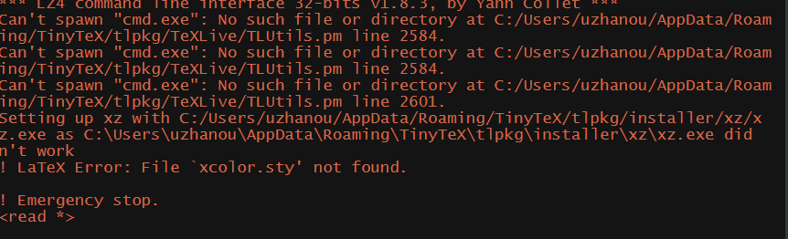

Cannot knit PDF error

OK, fine! Let’s **debugging**.

I first went to search the [**stackoverflow**](https://stackoverflow.com/) and found that after version 1.8, Rmarkdown automatically connects to package-TinyTex.

Then I went to [TinyTex webpage](https://yihui.org/tinytex/r/) and it seems like there are some answers to my problem.

[figure not shown]

TinyTex

After more than 2 days trials, I thought it might be a good idea to post my issue to the online community so that the expert (probably Yihui himself) could help me out.

[My question post](https://community.rstudio.com/t/tinytex-isnt-working-and-cant-generate-pdf-file-in-rmarkdown/53916)

After 12 hours, I even received Yihui’s reply–> Oh Yeah!

[figure not shown]

Yihui reply

However, nothing really worked out:(

my Rstudio constantly received this error message.

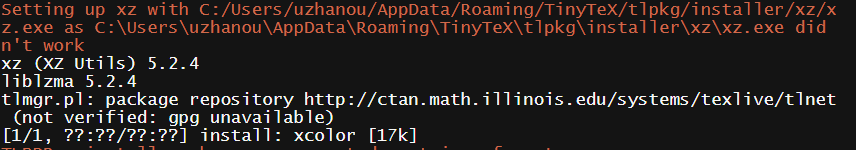

What a creepy error

Alright then! I came and I tried. Now it’s time to move on and reinstall the entire WINDOWS system, I guess.

The possible root cause might be I have installed multiple versions of Latex distribution in the past.

But anyway, it’s a good debugging experience and at least, I let my patience play out entire process.

[figure not shown]